# Permutation tests and the bootstrap

## Birth weights

```r
library(tidyverse)
library(mosaic)
library(ggformula)

d <- MASS::birthwt %>%
  mutate(race = factor(race, levels = 1:3, labels = c("white", "black", "other")),
         low = factor(low, levels = c(1,0), labels = c("Low", "Normal")),
         smoke = factor(smoke, levels = c(1,0), labels = c("smoker", "non_smoker")),
         lwt_kg = round(0.453592 * lwt,1))  # mother's weight: convert pounds to kg)

head(d, 4)
```

```
      low age lwt  race      smoke ptl ht ui ftv  bwt lwt_kg
85 Normal  19 182 black non_smoker   0  0  1   0 2523   82.6
86 Normal  33 155 other non_smoker   0  0  0   3 2551   70.3
87 Normal  20 105 white     smoker   0  0  0   1 2557   47.6
88 Normal  21 108 white     smoker   0  0  1   2 2594   49.0
```

## Mother’s weight

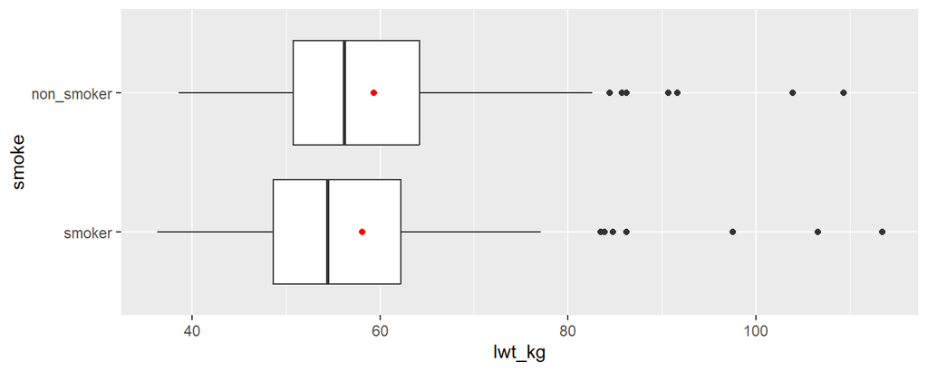

```r
gf_boxplot(lwt_kg ~ smoke, data = d) %>%
  gf_summary(fun = mean, geom = "point", color = "red") %>%
  gf_refine(coord_flip())
```

## Wilcoxon rank sum test

```r
wilcox.test(lwt_kg ~ smoke, data = d)
```

```
    Wilcoxon rank sum test with continuity correction

data:  lwt_kg by smoke
W = 3826, p-value = 0.2427
alternative hypothesis: true location shift is not equal to 0
```

No evidence of a difference in location.

## Hodges-Lehmann estimator (*pseudomedian*)

```r
wilcox.test(lwt_kg ~ smoke, data = d, conf.int =TRUE)
```

```
    Wilcoxon rank sum test with continuity correction

data:  lwt_kg by smoke
W = 3826, p-value = 0.2427
alternative hypothesis: true location shift is not equal to 0
95 percent confidence interval:
 -5.0000440  0.9000178
sample estimates:
difference in location
             -2.199988
```

Estimates the difference in location:

- This is NOT the difference of medians (a common missconception)
- Rather, it is the median of the differences computed for all possible pairs of a smoker and a non-smoker.

Not an easy interpretation.

## Permutation tests and the bootstrap

Both procedures are distribution-free: do not require normality assumption.

- [Permutation tests](https://en.wikipedia.org/wiki/Permutation_test) (sometimes called randomization tests) are more suited to hypothesis testing.
- [The bootstrap](https://www.bmj.com/content/350/bmj.h2622) is more suited to confidence interval estimation.

However, both can produce p-values and confidence intervals.

Can be applied to many sample statistics (but we will concentrate on means).

For an in depth coverage of the topic, see:

[Brian Efron and Robert J. Tibshirani. An introduction to the bootstrap](https://books.google.co.cr/books?id=gLlpIUxRntoC&printsec=frontcover&hl=es#v=onepage&q&f=false)

## Permutation test

```r
set.seed(1)                                  # for reproducibility
MKinfer::perm.t.test(lwt_kg ~ smoke, data = d)
```

```
    Permutation Welch Two Sample t-test

data:  lwt_kg by smoke
number of permutations:  9999
(Monte-Carlo) permutation p-value = 0.5628
permutation difference of means (SE) = -1.273898 (2.066187)
95 percent (Monte-Carlo) permutation percentile confidence interval:
 -5.302456  2.813106

Results without permutation:
t = -0.58618, df = 136.52, p-value = 0.5587
alternative hypothesis: true difference in means is not equal to 0
95 percent confidence interval:
 -5.509848  2.990201
sample estimates:
    mean in group smoker mean in group non_smoker
                58.11757                 59.37739
```

No evidence of a difference in means.

## Boostrap

```r
set.seed(1)                                  # for reproducibility
MKinfer::boot.t.test(lwt_kg ~ smoke, data = d)
```

```
    Bootstrap Welch Two Sample t-test

data:  lwt_kg by smoke
number of bootstrap samples:  9999
bootstrap p-value = 0.5845
bootstrap difference of means (SE) = -1.30374 (2.125572)
95 percent bootstrap percentile confidence interval:
 -5.458622  2.983990

Results without bootstrap:
t = -0.58618, df = 136.52, p-value = 0.5587
alternative hypothesis: true difference in means is not equal to 0
95 percent confidence interval:
 -5.509848  2.990201
sample estimates:
    mean in group smoker mean in group non_smoker
                58.11757                 59.37739
```

## Exercise

The file erosive_esophagitis.xls contains data on a clinical trial comparing two treatments (A or B) for severe erosive esophagitis. The primary efficacy endpoint was the healing of all erosions as determined by endoscopy after eight weeks of therapy.

Total cost of care (US dollars 1992) were recorded, including study drug, concomitant antacids, all non-protocol driven medical costs (i.e., physician visits, emergency room visits, treatment of adverse effects, procedures, etc.).

Questions:

1. Is there any evidence of different costs depending on the treatment?
2. What is the estimate of the difference in mean costs with A or B?